# Fire hotspots in Edmonton, 2024

Author

Matt Ashby

Published

1 March 2025

**ImportantThis is an example report used for teaching purposes**

This is an example report used to help students understand how different types of report can be created using the Quarto markup language and the R programming language. **This contents of this report should not be relied upon for operational use.**

This report has been prepared for Edmonton Fire Rescue Services (EFRS) to identify hotspot locations for fires in the city of Edmonton during the calendar year 2024. This report is based on the [EFRS Fire Response dataset](https://data.edmonton.ca/d/7hsn-idqi). The information in this dataset is recorded by EFRS staff while co-ordinating the response to each incident. The large volume of incidents and rapid pace of operations in a fire control room mean it is likely the data will contain some errors, but it is not possible to quantify these or assess how they might affect the conclusions drawn in this report. However, it is likely the majority of recording errors are effectively random, and so are unlikely to bias this analysis towards a particular conclusion.

Between 1 January and 31 December 2024, EFRS responded to a total of 86,815 incidents, with an average of 237 per day. Of those, 58% were classified as medical, 17% as alarms, 12% as fire, 7% as motor vehicle incident, 3% as other, and 3% as citizen assist (e.g. animal rescue or person trapped in a lift). The rest of this report will focus on the 12% of incidents that were categorised as fires.

Figure 1: Locations of calls to fires in Edmonton, 2024

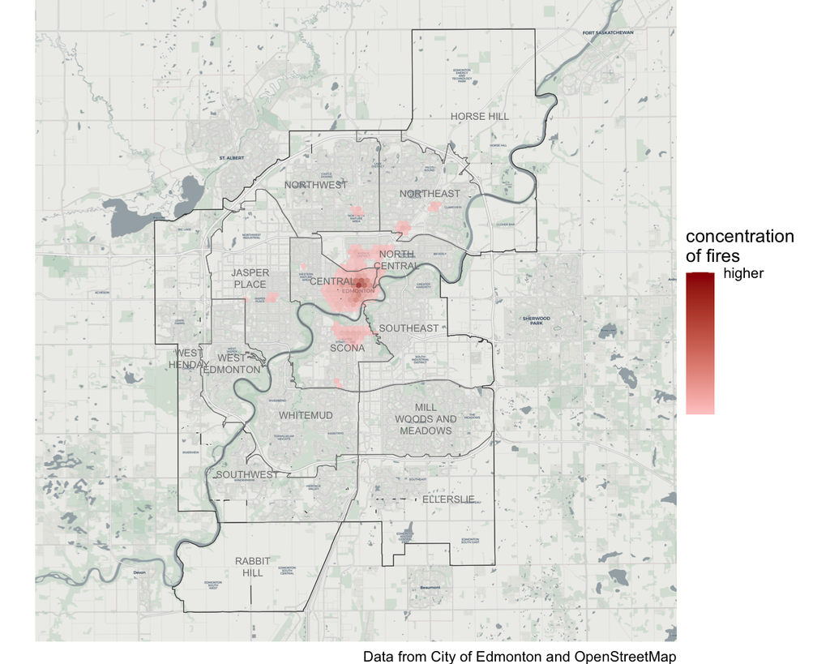

Figure 1 shows locations in the city of Edmonton with more fires than would be expected by chance. The map shows that fires are very heavily concentrated in a small area in downtown Edmonton. There were 888 fires within 1 kilometre of this point in 2024, around 8% of all fires in Edmonton in that period. This is despite that area being only 0.1% of the area of the city.

Figure 2: Locations of calls to fires in downtown Edmonton, 2024

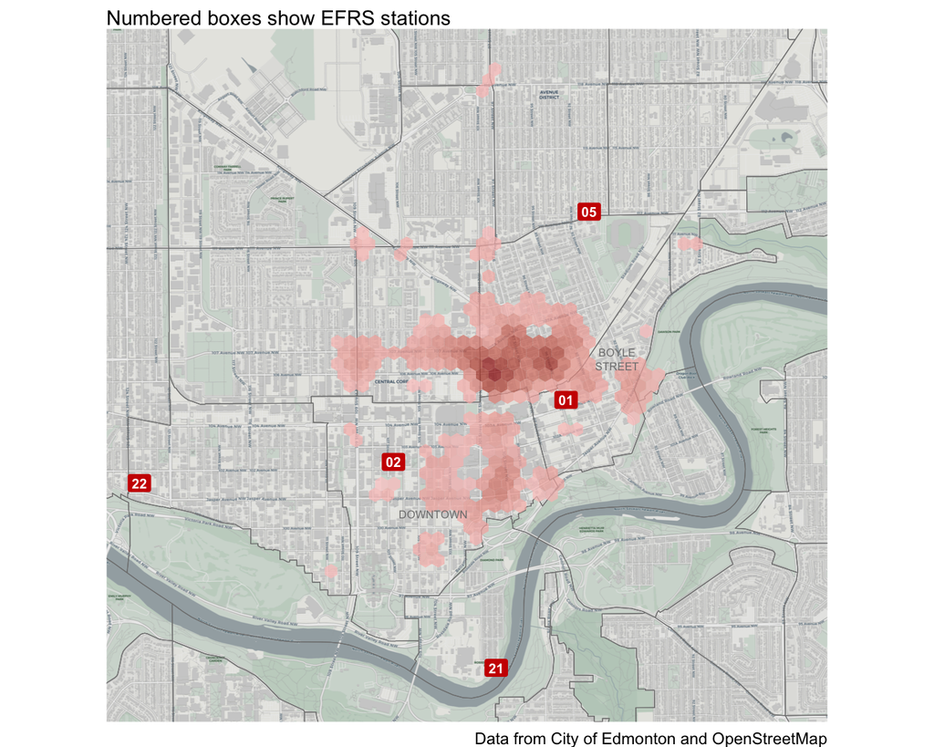

Figure 2 shows the places within downtown Edmonton with more fires than would be expected by chance. This shows that fires are concentrated around the Downtown and Boyle Street neighbourhoods, as well as along the 107th Avenue corridor.

Figure 3: Frequency of different types of fire in Edmonton, 2024

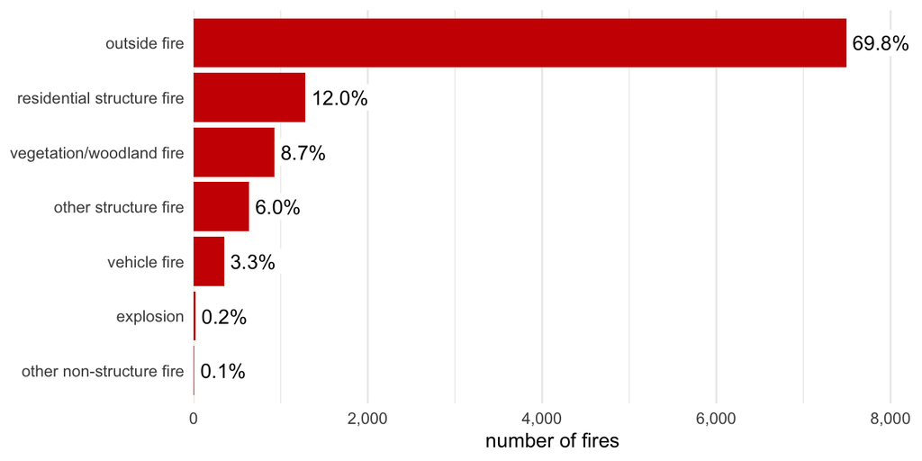

Figure 3 shows the number of fires of each type that were recorded as occurring in Edmonton in 2024. More than two thirds of fires were outdoor fires, e.g. a fire caused by a lightning strike or illegal burning of rubbish. The majority of structure fires were in residential structures.

Figure 4 shows where the four most-common types of fire concentrated. Outside fires are heavily concentrated downtown, while the other types of fire are more widely distributed. While 45% of all outside fires occurred in the Central district (one of 15 districts in Edmonton), the district with the highest proportion of residential structure fires had only 18% of all such fires in the city. Table 1 shows the number of fires of each type in each district.

Figure 4: Locations of calls to different types of fire in Edmonton, 2024

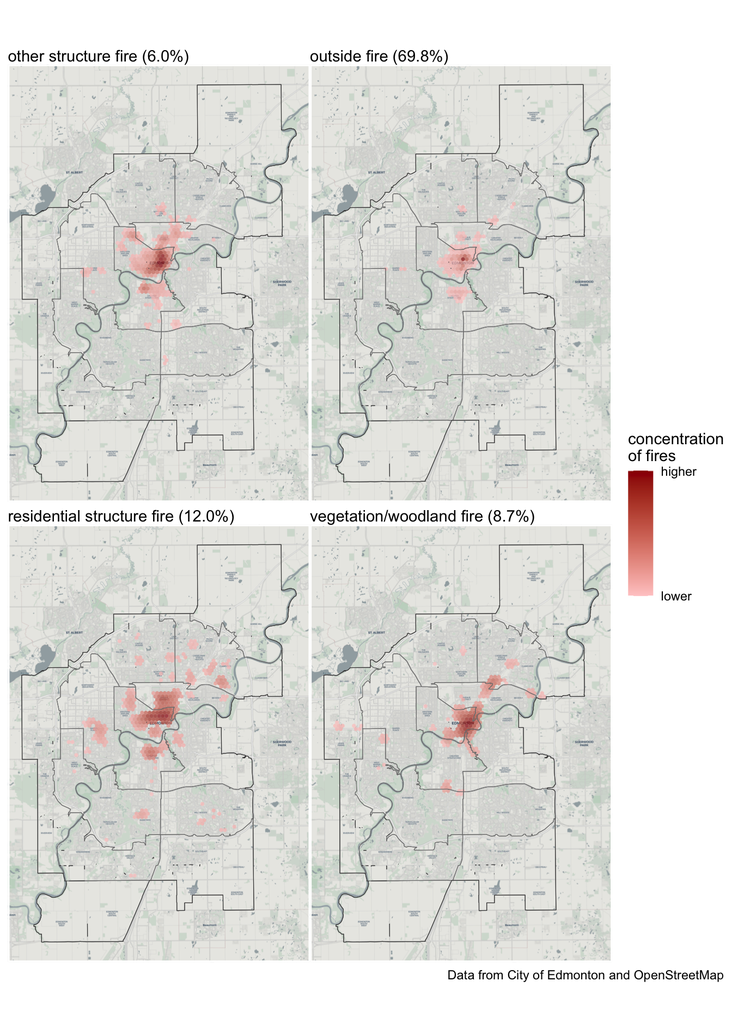

Table 1: Number of fires of each type in each Edmonton district, 2024

|  | type of fire outside | type of fire residential structure | type of fire vegetation/ woodland | type of fire other structure | type of fire vehicle | type of fire explosion | type of fire other non-structure |
| --- | --- | --- | --- | --- | --- | --- | --- |
| Central | 3,408 | 227 | 203 | 201 | 32 | 8 | 0 |
| Ellerslie | 43 | 24 | 20 | 6 | 21 | 0 | 0 |
| Horse Hill | 13 | 4 | 14 | 6 | 4 | 0 | 0 |
| Jasper Place | 523 | 87 | 51 | 51 | 36 | 3 | 0 |
| Mill Woods and Meadows | 291 | 119 | 39 | 32 | 25 | 1 | 2 |
| North Central | 801 | 140 | 119 | 86 | 27 | 2 | 1 |
| Northeast | 438 | 175 | 118 | 41 | 35 | 3 | 4 |
| Northwest | 411 | 127 | 59 | 43 | 40 | 3 | 0 |
| Rabbit Hill | 1 | 1 | 4 | 1 | 4 | 0 | 0 |
| Scona | 760 | 98 | 87 | 75 | 11 | 1 | 0 |
| Southeast | 330 | 66 | 69 | 48 | 36 | 1 | 0 |
| Southwest | 42 | 64 | 14 | 11 | 14 | 1 | 0 |
| West Edmonton | 189 | 44 | 36 | 16 | 15 | 0 | 1 |
| West Henday | 75 | 32 | 55 | 11 | 22 | 0 | 0 |
| Whitemud | 177 | 77 | 35 | 11 | 24 | 0 | 0 |
| Edmonton | 7,502 | 1,285 | 923 | 639 | 346 | 23 | 8 |

Column shading shows number of fires